# HTML report

https://www.kaggle.com/datasets/shantanudhakadd/diabetes-dataset-for-beginners

#1. PROBLEM DEFINITION The objective of the dataset is to diagnostically predict whether or not a patient has diabetes, based on certain diagnostic measurements included in the dataset.

#2.DATA The dataset was downloade at this site https://www.kaggle.com/datasets/shantanudhakadd/diabetes-dataset-for-beginners This dataset is originally from the National Institute of Diabetes and Digestive and Kidney Diseases. The objective of the dataset is to diagnostically predict whether or not a patient has diabetes, based on certain diagnostic measurements included in the dataset. Several constraints were placed on the selection of these instances from a larger database. In particular, all patients here are females at least 21 years old of Pima Indian heritage

#3.EVALUATION

The method of evaluation in this project was to find the `accuracy` of each model

#4.FEATURES The dataset consists of several medical predictor variables and one target variable, Outcome. Predictor variables includes the number of pregnancies the patient has had, their BMI, insulin level, age, and so on.

##1.load libraries

##2.load dataset

```
Rows: 768
Columns: 9
$ Pregnancies              <dbl> 6, 1, 8, 1, 0, 5, 3, 10, 2, 8, 4, 10, 10, 1, 5, 7, 0, 7, 1, 1, 3, 8, 7, 9, 11, 10, 7, 1, 13, 5, 5, 3, 3, 6, 10, 4, 11, 9, 2, 4, 3, 7, 7, 9, 7, 0, 1, 2, 7, 7, 1, 1, 5, 8, 7, 1, 7, 0, 0, 0, 2, 8, 5, 2, 7, 5, 0, 2, 1, …
$ Glucose                  <dbl> 148, 85, 183, 89, 137, 116, 78, 115, 197, 125, 110, 168, 139, 189, 166, 100, 118, 107, 103, 115, 126, 99, 196, 119, 143, 125, 147, 97, 145, 117, 109, 158, 88, 92, 122, 103, 138, 102, 90, 111, 180, 133, 106, 171, 159…
$ BloodPressure            <dbl> 72, 66, 64, 66, 40, 74, 50, 0, 70, 96, 92, 74, 80, 60, 72, 0, 84, 74, 30, 70, 88, 84, 90, 80, 94, 70, 76, 66, 82, 92, 75, 76, 58, 92, 78, 60, 76, 76, 68, 72, 64, 84, 92, 110, 64, 66, 56, 70, 66, 0, 80, 50, 66, 90, 6…
$ SkinThickness            <dbl> 35, 29, 0, 23, 35, 0, 32, 0, 45, 0, 0, 0, 0, 23, 19, 0, 47, 0, 38, 30, 41, 0, 0, 35, 33, 26, 0, 15, 19, 0, 26, 36, 11, 0, 31, 33, 0, 37, 42, 47, 25, 0, 18, 24, 0, 39, 0, 27, 32, 0, 11, 15, 21, 34, 42, 10, 39, 60, 0,…
$ Insulin                  <dbl> 0, 0, 0, 94, 168, 0, 88, 0, 543, 0, 0, 0, 0, 846, 175, 0, 230, 0, 83, 96, 235, 0, 0, 0, 146, 115, 0, 140, 110, 0, 0, 245, 54, 0, 0, 192, 0, 0, 0, 207, 70, 0, 0, 240, 0, 0, 0, 0, 0, 0, 82, 36, 23, 300, 342, 0, 304, 1…
$ BMI                      <dbl> 33.6, 26.6, 23.3, 28.1, 43.1, 25.6, 31.0, 35.3, 30.5, 0.0, 37.6, 38.0, 27.1, 30.1, 25.8, 30.0, 45.8, 29.6, 43.3, 34.6, 39.3, 35.4, 39.8, 29.0, 36.6, 31.1, 39.4, 23.2, 22.2, 34.1, 36.0, 31.6, 24.8, 19.9, 27.6, 24.0, …
$ DiabetesPedigreeFunction <dbl> 0.627, 0.351, 0.672, 0.167, 2.288, 0.201, 0.248, 0.134, 0.158, 0.232, 0.191, 0.537, 1.441, 0.398, 0.587, 0.484, 0.551, 0.254, 0.183, 0.529, 0.704, 0.388, 0.451, 0.263, 0.254, 0.205, 0.257, 0.487, 0.245, 0.337, 0.546…
$ Age                      <dbl> 50, 31, 32, 21, 33, 30, 26, 29, 53, 54, 30, 34, 57, 59, 51, 32, 31, 31, 33, 32, 27, 50, 41, 29, 51, 41, 43, 22, 57, 38, 60, 28, 22, 28, 45, 33, 35, 46, 27, 56, 26, 37, 48, 54, 40, 25, 29, 22, 31, 24, 22, 26, 30, 58,…
$ Outcome                  <dbl> 1, 0, 1, 0, 1, 0, 1, 0, 1, 1, 0, 1, 0, 1, 1, 1, 1, 1, 0, 1, 0, 0, 1, 1, 1, 1, 1, 0, 0, 0, 0, 1, 0, 0, 0, 0, 0, 1, 1, 1, 0, 0, 0, 1, 0, 1, 0, 0, 1, 0, 0, 0, 0, 1, 0, 0, 1, 0, 0, 0, 0, 1, 0, 0, 1, 0, 1, 0, 0, 0, 1, 0,…
```

``OBSERVATION`:the dataset has only double datatype

##3.Data analysis of the data

```
[1] "tbl_df"     "tbl"        "data.frame"
```

```
[1] 768   9
```

| value |
| --- |
| Pregnancies |
| Glucose |
| BloodPressure |
| SkinThickness |
| Insulin |
| BMI |
| DiabetesPedigreeFunction |
| Age |
| Outcome |

| Pregnancies | Glucose | BloodPressure | SkinThickness | Insulin | BMI | DiabetesPedigreeFunction | Age | Outcome |
| --- | --- | --- | --- | --- | --- | --- | --- | --- |
| 6 | 148 | 72 | 35 | 0 | 33.6 | 0.627 | 50 | 1 |
| 1 | 85 | 66 | 29 | 0 | 26.6 | 0.351 | 31 | 0 |
| 8 | 183 | 64 | 0 | 0 | 23.3 | 0.672 | 32 | 1 |
| 1 | 89 | 66 | 23 | 94 | 28.1 | 0.167 | 21 | 0 |
| 0 | 137 | 40 | 35 | 168 | 43.1 | 2.288 | 33 | 1 |
| 5 | 116 | 74 | 0 | 0 | 25.6 | 0.201 | 30 | 0 |

| Pregnancies | Glucose | BloodPressure | SkinThickness | Insulin | BMI | DiabetesPedigreeFunction | Age | Outcome |
| --- | --- | --- | --- | --- | --- | --- | --- | --- |
| 9 | 89 | 62 | 0 | 0 | 22.5 | 0.142 | 33 | 0 |
| 10 | 101 | 76 | 48 | 180 | 32.9 | 0.171 | 63 | 0 |
| 2 | 122 | 70 | 27 | 0 | 36.8 | 0.340 | 27 | 0 |
| 5 | 121 | 72 | 23 | 112 | 26.2 | 0.245 | 30 | 0 |
| 1 | 126 | 60 | 0 | 0 | 30.1 | 0.349 | 47 | 1 |
| 1 | 93 | 70 | 31 | 0 | 30.4 | 0.315 | 23 | 0 |

```
  Pregnancies        Glucose      BloodPressure    SkinThickness      Insulin           BMI        DiabetesPedigreeFunction      Age           Outcome
 Min.   : 0.000   Min.   :  0.0   Min.   :  0.00   Min.   : 0.00   Min.   :  0.0   Min.   : 0.00   Min.   :0.0780           Min.   :21.00   Min.   :0.000
 1st Qu.: 1.000   1st Qu.: 99.0   1st Qu.: 62.00   1st Qu.: 0.00   1st Qu.:  0.0   1st Qu.:27.30   1st Qu.:0.2437           1st Qu.:24.00   1st Qu.:0.000
 Median : 3.000   Median :117.0   Median : 72.00   Median :23.00   Median : 30.5   Median :32.00   Median :0.3725           Median :29.00   Median :0.000
 Mean   : 3.845   Mean   :120.9   Mean   : 69.11   Mean   :20.54   Mean   : 79.8   Mean   :31.99   Mean   :0.4719           Mean   :33.24   Mean   :0.349
 3rd Qu.: 6.000   3rd Qu.:140.2   3rd Qu.: 80.00   3rd Qu.:32.00   3rd Qu.:127.2   3rd Qu.:36.60   3rd Qu.:0.6262           3rd Qu.:41.00   3rd Qu.:1.000
 Max.   :17.000   Max.   :199.0   Max.   :122.00   Max.   :99.00   Max.   :846.0   Max.   :67.10   Max.   :2.4200           Max.   :81.00   Max.   :1.000
```

`obsrevation`:The dataset needs to be standardized.

Data summary

| Name | Piped data |
| --- | --- |
| Number of rows | 768 |
| Number of columns | 9 |
| _______________________ |  |
| Column type frequency: |  |
| numeric | 9 |
| ________________________ |  |
| Group variables | None |

**Variable type: numeric**

| skim_variable | n_missing | complete_rate | mean | sd | p0 | p25 | p50 | p75 | p100 | hist |
| --- | --- | --- | --- | --- | --- | --- | --- | --- | --- | --- |
| Pregnancies | 0 | 1 | 3.85 | 3.37 | 0.00 | 1.00 | 3.00 | 6.00 | 17.00 | ▇▃▂▁▁ |
| Glucose | 0 | 1 | 120.89 | 31.97 | 0.00 | 99.00 | 117.00 | 140.25 | 199.00 | ▁▁▇▆▂ |
| BloodPressure | 0 | 1 | 69.11 | 19.36 | 0.00 | 62.00 | 72.00 | 80.00 | 122.00 | ▁▁▇▇▁ |
| SkinThickness | 0 | 1 | 20.54 | 15.95 | 0.00 | 0.00 | 23.00 | 32.00 | 99.00 | ▇▇▂▁▁ |
| Insulin | 0 | 1 | 79.80 | 115.24 | 0.00 | 0.00 | 30.50 | 127.25 | 846.00 | ▇▁▁▁▁ |
| BMI | 0 | 1 | 31.99 | 7.88 | 0.00 | 27.30 | 32.00 | 36.60 | 67.10 | ▁▃▇▂▁ |
| DiabetesPedigreeFunction | 0 | 1 | 0.47 | 0.33 | 0.08 | 0.24 | 0.37 | 0.63 | 2.42 | ▇▃▁▁▁ |
| Age | 0 | 1 | 33.24 | 11.76 | 21.00 | 24.00 | 29.00 | 41.00 | 81.00 | ▇▃▁▁▁ |
| Outcome | 0 | 1 | 0.35 | 0.48 | 0.00 | 0.00 | 0.00 | 1.00 | 1.00 | ▇▁▁▁▅ |

```
[1] 0
```

| Outcome | n | prop |
| --- | --- | --- |
| 0 | 500 | 0.6510417 |
| 1 | 268 | 0.3489583 |

The outcomes o and 1 are fairly distributed.

#Relationship between bloodpressure and age

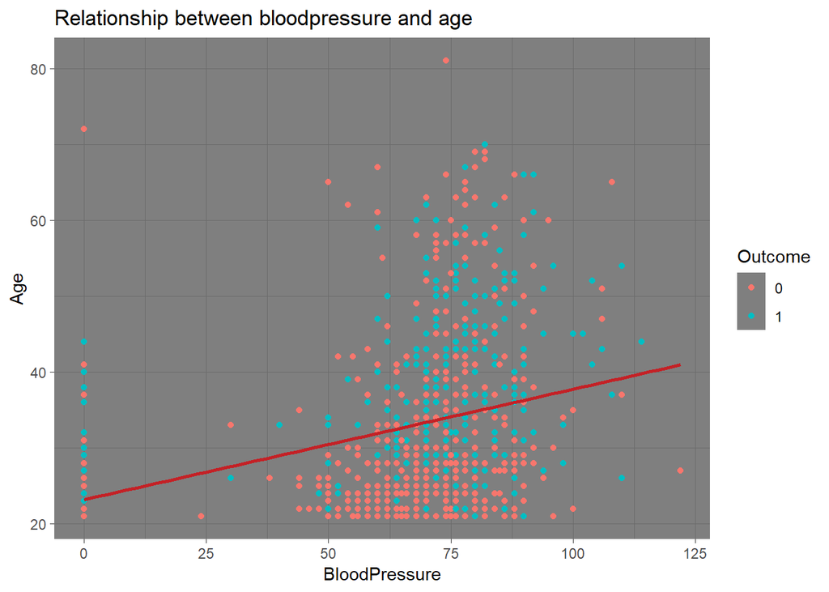

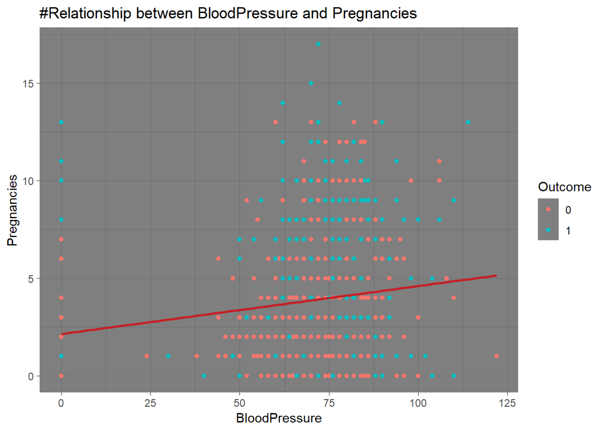

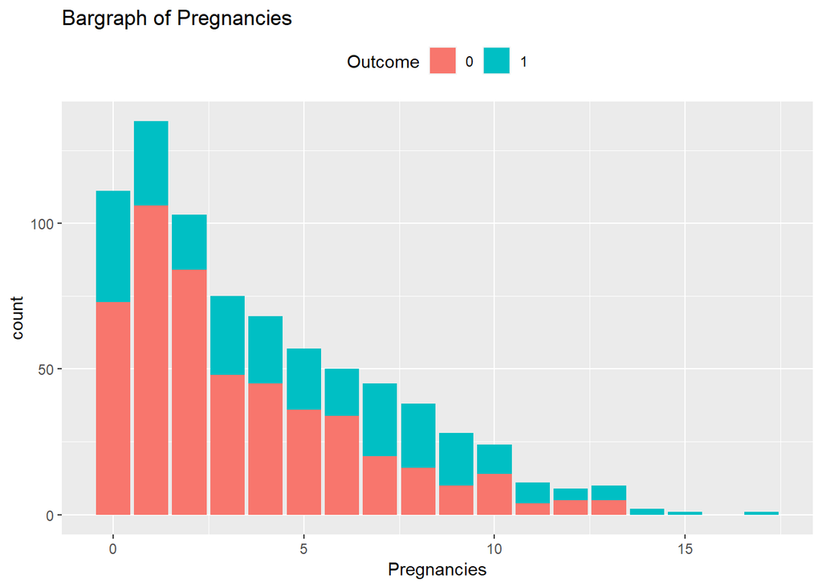

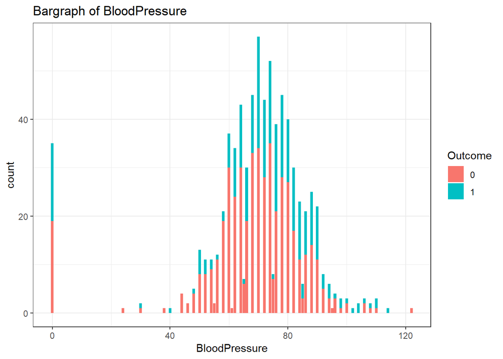

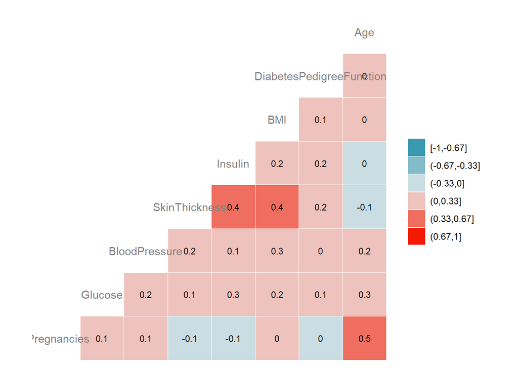

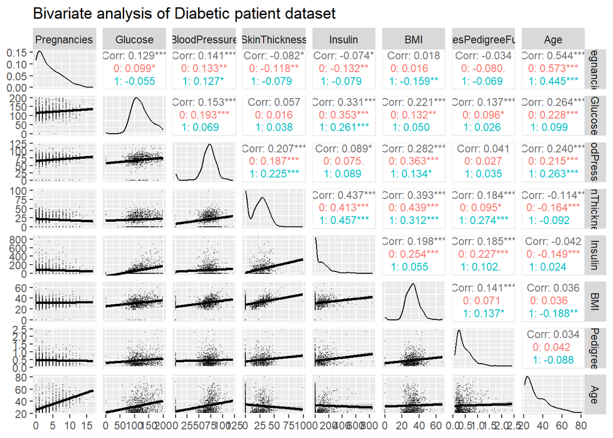

`OBSERVATION`: Glucose,Blood Pressure and BMI have normal distribution while the rest do not have normal distribution which calls for the data to be standardized.

##4.Data splitting and creating V-folds

| Pregnancies | Glucose | BloodPressure | SkinThickness | Insulin | BMI | DiabetesPedigreeFunction | Age | Outcome |
| --- | --- | --- | --- | --- | --- | --- | --- | --- |
| 6 | 148 | 72 | 35 | 0 | 33.6 | 0.627 | 50 | 1 |
| 1 | 85 | 66 | 29 | 0 | 26.6 | 0.351 | 31 | 0 |
| 8 | 183 | 64 | 0 | 0 | 23.3 | 0.672 | 32 | 1 |
| 1 | 89 | 66 | 23 | 94 | 28.1 | 0.167 | 21 | 0 |
| 0 | 137 | 40 | 35 | 168 | 43.1 | 2.288 | 33 | 1 |
| 5 | 116 | 74 | 0 | 0 | 25.6 | 0.201 | 30 | 0 |

| Outcome | n | prop |
| --- | --- | --- |
| 0 | 375 | 0.6510417 |
| 1 | 201 | 0.3489583 |

| splits | id |
| --- | --- |
|  | Fold01 |
|  | Fold02 |
|  | Fold03 |
|  | Fold04 |
|  | Fold05 |
|  | Fold06 |
|  | Fold07 |
|  | Fold08 |
|  | Fold09 |
|  | Fold10 |

##5.A FIRST MODEL:RANDOM FOREST

In feature engineering we will use Random Search definition ##Set the control parameter To Set the control parameter i will proceed as follow to construct and evaluate the model:

1.Evaluate the model with the default setting 2.Find the best number of mtry 3.Find the best number of maxnodes 4.Find the best number of ntrees 5.Evaluate the model on the test dataset

Step 1)Evaluate the model with the default setting

```
Random Forest

576 samples
  8 predictor
  2 classes: '0', '1'

No pre-processing
Resampling: Cross-Validated (10 fold)
Summary of sample sizes: 518, 519, 518, 517, 518, 519, ...
Resampling results across tuning parameters:

  mtry  Accuracy   Kappa
  2     0.7465979  0.4294911
  5     0.7466302  0.4254417
  8     0.7397326  0.4130740

Accuracy was used to select the optimal model using the largest value.
The final value used for the model was mtry = 5.
```

Step 2) Search best mtry

```
Random Forest

576 samples
  8 predictor
  2 classes: '0', '1'

No pre-processing
Resampling: Cross-Validated (10 fold)
Summary of sample sizes: 518, 519, 518, 517, 518, 519, ...
Resampling results across tuning parameters:

  mtry  Accuracy   Kappa
   1    0.7483804  0.4171219
   2    0.7483502  0.4252732
   3    0.7535539  0.4431737
   4    0.7570042  0.4527424
   5    0.7501056  0.4374476
   6    0.7501359  0.4343917
   7    0.7448132  0.4218666
   8    0.7484702  0.4311154
   9    0.7484712  0.4312956
  10    0.7484127  0.4309099

Accuracy was used to select the optimal model using the largest value.
The final value used for the model was mtry = 4.
```

```
[1] 0.7570042
```

```
[1] 4
```

Step 3) Search the best maxnodes I will create a loop to evaluate the different values of maxnodes. In the following code,I will:

1.Create a list 2.Create a variable with the best value of the parameter mtry; Compulsory 3.Create the loop 4.Store the current value of maxnode 5.Summarize the results

```
Call:
summary.resamples(object = results_mtry)

Models: 5, 6, 7, 8, 9, 10, 11, 12, 13, 14, 15
Number of resamples: 10

Accuracy
        Min.   1st Qu.    Median      Mean   3rd Qu.      Max. NA's
5  0.6315789 0.6926800 0.7304900 0.7357532 0.7887931 0.8448276    0
6  0.5964912 0.6926800 0.7566546 0.7409558 0.7887931 0.8620690    0
7  0.6491228 0.7273140 0.7478826 0.7514217 0.7844828 0.8620690    0
8  0.6315789 0.7099970 0.7392619 0.7409861 0.7715517 0.8620690    0
9  0.6491228 0.7273140 0.7500000 0.7514217 0.7878100 0.8448276    0
10 0.6491228 0.7273140 0.7500000 0.7532063 0.7748790 0.8448276    0
11 0.6491228 0.7413793 0.7565033 0.7549304 0.7748790 0.8448276    0
12 0.6842105 0.7241379 0.7477314 0.7515124 0.7748790 0.8275862    0
13 0.6666667 0.7143829 0.7500000 0.7532365 0.7921960 0.8275862    0
14 0.7017544 0.7241379 0.7563521 0.7637024 0.7921960 0.8448276    0
15 0.6842105 0.7280702 0.7586207 0.7602238 0.7878100 0.8275862    0

Kappa
        Min.   1st Qu.    Median      Mean   3rd Qu.      Max. NA's
5  0.1623513 0.2549056 0.3803978 0.3741724 0.4770122 0.6439291    0
6  0.1038961 0.2692544 0.4364030 0.3942335 0.4846204 0.6873315    0
7  0.2116183 0.3565461 0.4153346 0.4207361 0.5012560 0.6873315    0
8  0.1623513 0.3069195 0.3969801 0.3930299 0.4677530 0.6873315    0
9  0.2116183 0.3576451 0.4296893 0.4234274 0.5098667 0.6524634    0
10 0.2116183 0.3576451 0.4296893 0.4298860 0.4846204 0.6524634    0
11 0.2116183 0.4063246 0.4375705 0.4371011 0.4846204 0.6524634    0
12 0.2733711 0.3565461 0.4150057 0.4272685 0.4846204 0.6184211    0
13 0.2597403 0.3372263 0.4222193 0.4307529 0.5250625 0.6184211    0
14 0.3219034 0.3616607 0.4379756 0.4559215 0.5250625 0.6524634    0
15 0.2904564 0.3785335 0.4460284 0.4488790 0.5006755 0.6184211    0
```

You can try with higher values to see if you can get a higher score.

```
Call:
summary.resamples(object = results_node)

Models: 20, 21, 22, 23, 24, 25, 26, 27, 28, 29, 30
Number of resamples: 10

Accuracy
        Min.   1st Qu.    Median      Mean   3rd Qu.      Max. NA's
20 0.6551724 0.7253068 0.7477314 0.7518892 0.7982456 0.8275862    0
21 0.6896552 0.7137229 0.7477314 0.7519184 0.7850877 0.8275862    0
22 0.6551724 0.7143829 0.7500743 0.7553083 0.7860708 0.8448276    0
23 0.6551724 0.7216771 0.7456140 0.7484107 0.7817604 0.8275862    0
24 0.6551724 0.7061404 0.7500743 0.7518297 0.7992287 0.8448276    0
25 0.6551724 0.7085192 0.7456140 0.7484107 0.7992287 0.8275862    0
26 0.6551724 0.7236842 0.7500743 0.7518600 0.7949183 0.8275862    0
27 0.6551724 0.6970659 0.7413024 0.7378854 0.7860708 0.7931034    0
28 0.6551724 0.7192982 0.7500743 0.7501661 0.7758621 0.8245614    0
29 0.6551724 0.7099970 0.7585489 0.7482918 0.7992287 0.8103448    0
30 0.6551724 0.7099970 0.7497770 0.7500461 0.7992287 0.8245614    0

Kappa
        Min.   1st Qu.    Median      Mean   3rd Qu.      Max. NA's
20 0.2368421 0.3295087 0.4193707 0.4313791 0.5362798 0.6058091    0
21 0.2739323 0.3625123 0.4193707 0.4332818 0.5046646 0.5784884    0
22 0.2368421 0.3604612 0.4493146 0.4425659 0.4929240 0.6410077    0
23 0.2368421 0.3961405 0.4193707 0.4279996 0.4959512 0.5892351    0
24 0.2368421 0.3604750 0.4493146 0.4367334 0.5437741 0.6255380    0
25 0.2368421 0.3634407 0.4439841 0.4286454 0.5281059 0.5892351    0
26 0.2368421 0.4006876 0.4341882 0.4378781 0.5311331 0.5784884    0
27 0.2368421 0.3260135 0.4341882 0.4040278 0.4854172 0.5269710    0
28 0.2368421 0.3872434 0.4493146 0.4343716 0.4694672 0.6058091    0
29 0.2544987 0.3260135 0.4660149 0.4317824 0.5335173 0.5612316    0
30 0.2368421 0.3604750 0.4439841 0.4334376 0.5182576 0.5963173    0
```

```
Call:
summary.resamples(object = results_node)

Models: 40, 41, 42, 43, 44, 45, 46, 47, 48, 49, 50
Number of resamples: 10

Accuracy
        Min.   1st Qu.    Median      Mean   3rd Qu.      Max. NA's
40 0.6896552 0.7099970 0.7585489 0.7587273 0.8123866 0.8275862    0
41 0.6551724 0.7014519 0.7500743 0.7466573 0.7887931 0.8245614    0
42 0.6551724 0.7216771 0.7456140 0.7484409 0.7860708 0.8245614    0
43 0.6551724 0.7205082 0.7500743 0.7483210 0.7860708 0.8245614    0
44 0.6724138 0.7205082 0.7497770 0.7499856 0.7992287 0.8103448    0
45 0.6551724 0.7205082 0.7497770 0.7500159 0.7992287 0.8103448    0
46 0.6551724 0.7205082 0.7497770 0.7465374 0.7887931 0.8070175    0
47 0.6551724 0.7205082 0.7497770 0.7465374 0.7887931 0.8070175    0
48 0.6551724 0.7205082 0.7497770 0.7465374 0.7887931 0.8070175    0
49 0.6551724 0.7205082 0.7497770 0.7465374 0.7887931 0.8070175    0
50 0.6551724 0.7205082 0.7497770 0.7465374 0.7887931 0.8070175    0

Kappa
        Min.   1st Qu.    Median      Mean   3rd Qu.      Max. NA's
40 0.2412791 0.3651267 0.4660149 0.4552736 0.5678520 0.6058091    0
41 0.2368421 0.3372820 0.4493146 0.4279456 0.4985415 0.5963173    0
42 0.2544987 0.3899682 0.4503260 0.4331320 0.4955143 0.5963173    0
43 0.2368421 0.3401320 0.4493146 0.4301647 0.5134581 0.5963173    0
44 0.2834850 0.3401320 0.4439841 0.4345844 0.5335173 0.5714286    0
45 0.2544987 0.3604750 0.4439841 0.4362806 0.5335173 0.5714286    0
46 0.2544987 0.3401320 0.4439841 0.4270093 0.5009256 0.5714286    0
47 0.2544987 0.3401320 0.4439841 0.4270093 0.5009256 0.5714286    0
48 0.2544987 0.3401320 0.4439841 0.4270093 0.5009256 0.5714286    0
49 0.2544987 0.3401320 0.4439841 0.4270093 0.5009256 0.5714286    0
50 0.2544987 0.3401320 0.4439841 0.4270093 0.5009256 0.5714286    0
```

`OBSERVATION`: 40 have the highest accuracy Of 0.7587273

##Step 4) Search the best ntrees

```
Call:
summary.resamples(object = results_tree)

Models: 250, 300, 350, 400, 450, 500, 550, 600, 800, 1000, 2000
Number of resamples: 10

Accuracy
          Min.   1st Qu.    Median      Mean   3rd Qu.      Max. NA's
250  0.6724138 0.7352067 0.7565033 0.7624458 0.8035390 0.8245614    0
300  0.6724138 0.7192431 0.7651240 0.7608416 0.8026316 0.8245614    0
350  0.6724138 0.7192431 0.7719298 0.7625658 0.8035390 0.8245614    0
400  0.6724138 0.7137229 0.7566546 0.7538543 0.7992287 0.8245614    0
450  0.6724138 0.7181088 0.7566546 0.7590570 0.8035390 0.8245614    0
500  0.6724138 0.7181088 0.7566546 0.7573328 0.8035390 0.8245614    0
550  0.6724138 0.7181088 0.7566546 0.7573328 0.8035390 0.8245614    0
600  0.6551724 0.7181088 0.7566546 0.7556087 0.8035390 0.8245614    0
800  0.6551724 0.7181088 0.7566546 0.7538846 0.8035390 0.8245614    0
1000 0.6551724 0.7181088 0.7566546 0.7556087 0.8035390 0.8245614    0
2000 0.6551724 0.7137229 0.7566546 0.7521302 0.8035390 0.8245614    0

Kappa
          Min.   1st Qu.    Median      Mean   3rd Qu.      Max. NA's
250  0.2482947 0.4042617 0.4438372 0.4565899 0.5456526 0.6058091    0
300  0.2482947 0.3707433 0.4461119 0.4521512 0.5446460 0.6058091    0
350  0.2482947 0.3708179 0.4739354 0.4581484 0.5456526 0.6058091    0
400  0.2482947 0.3366937 0.4440020 0.4378059 0.5343221 0.6058091    0
450  0.2482947 0.3659549 0.4440020 0.4502166 0.5456526 0.6058091    0
500  0.2482947 0.3489251 0.4440020 0.4472307 0.5456526 0.6058091    0
550  0.2482947 0.3489251 0.4440020 0.4472307 0.5456526 0.6058091    0
600  0.2183288 0.3489251 0.4440020 0.4442341 0.5456526 0.6058091    0
800  0.2183288 0.3489251 0.4440020 0.4396777 0.5456526 0.6058091    0
1000 0.2183288 0.3489251 0.4440020 0.4442341 0.5456526 0.6058091    0
2000 0.2183288 0.3366937 0.4440020 0.4347852 0.5456526 0.6058091    0
```

#Predation

```
Confusion Matrix and Statistics

          Reference
Prediction   0   1
         0 114  29
         1  11  38

               Accuracy : 0.7917
                 95% CI : (0.7273, 0.8468)
    No Information Rate : 0.651
    P-Value [Acc > NIR] : 0.00001513

                  Kappa : 0.511

 Mcnemar's Test P-Value : 0.00719

            Sensitivity : 0.9120
            Specificity : 0.5672
         Pos Pred Value : 0.7972
         Neg Pred Value : 0.7755
             Prevalence : 0.6510
         Detection Rate : 0.5938
   Detection Prevalence : 0.7448
      Balanced Accuracy : 0.7396

       'Positive' Class : 0
```

`OBSERVATION`: our random forest has an accuracy of 0.7917

##Logistic regression

#1.Build the model

```
Call:
glm(formula = formula, family = "binomial", data = df_other)

Deviance Residuals:
    Min       1Q   Median       3Q      Max
-2.5816  -0.7249  -0.4019   0.7215   2.8255

Coefficients:
                           Estimate Std. Error z value             Pr(>|z|)
(Intercept)              -8.5803848  0.8364518 -10.258 < 0.0000000000000002 ***
Pregnancies               0.1592543  0.0378022   4.213          0.000025219 ***
Glucose                   0.0374315  0.0044361   8.438 < 0.0000000000000002 ***
BloodPressure            -0.0148407  0.0060121  -2.468               0.0136 *
SkinThickness             0.0026907  0.0079739   0.337               0.7358
Insulin                  -0.0013874  0.0009784  -1.418               0.1562
BMI                       0.0877609  0.0172498   5.088          0.000000363 ***
DiabetesPedigreeFunction  0.9760253  0.3400166   2.871               0.0041 **
Age                       0.0102071  0.0109412   0.933               0.3509
---
Signif. codes:  0 '***' 0.001 '**' 0.01 '*' 0.05 '.' 0.1 ' ' 1

(Dispersion parameter for binomial family taken to be 1)

    Null deviance: 745.11  on 575  degrees of freedom
Residual deviance: 536.24  on 567  degrees of freedom
AIC: 554.24

Number of Fisher Scoring iterations: 5
```

```
    FALSE TRUE
  0   111   14
  1    29   38
```

```
[1] 0.7760417
```

#ROC curve

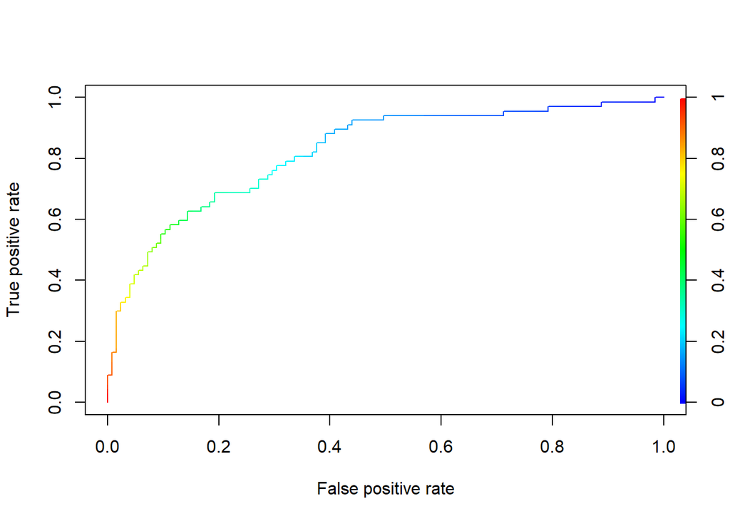

`CONCLUSION`: In the above project random forest model has an accuracy of 0.7917 while logistic regression has an accuracy of 0.7760417 on test set,hence the best model for this project is **random forest model**.